# Can Early ED Clinical Data Predict Whether Trauma Patients Will Need To Be Transferred To A Critical Care Unit?

Author

Rebekah Patel and 605566820

# Abstract

“We don’t have any beds!” is a repeated quote from the television show, *The Pitt*, which is one of the most realistic medical dramas ever aired, depicting the challenges of working in an Emergency Department (ED) in a busy metropolitan hospital. In each episode, the constant theme is that there are never enough beds in the ED to accommodate the number of patients who need care. This is a common problem in real life as well, and it can lead to worse outcomes for patients who need critical care but are not able to be transferred to an intensive care unit (ICU) in a timely manner. This project aims to develop a predictive model to identify trauma patients in the Emergency Department (ED) who are at high risk of requiring transfer to a critical care unit within 3 hours of admission. In doing so, more beds will open up faster and more patients will be seen. Using the MIMIC-IV database, we will build a cohort of trauma patients based on International Classification of Diseases (ICD) codes and extract relevant clinical data from the first 3 hours of their ED stay, including demographics, vital signs, laboratory results, and comorbidity information. We will then preprocess the data and train a lasso logistic regression model, random forest model, and an XGBoost model with class weights to address class imbalance, tuning the hyperparameters through 5-fold cross-validation. The model’s performance will be evaluated using metrics such as AUC-ROC, AUC-PR, sensitivity, and specificity. We will find that the XGBoost model is the most reliable model that identifies high risk trauma patients with the greatest sensitivity, which is one of the goals of this project. Finally, we will analyze feature importance to investigate the key predictors of early ICU transfer among trauma patients in the ED. From this dataset, we will find that certain features such as admission type and race are among the most important predictors of early ICU transfer. This project is just the starting point to eventually providing doctors with a tool to help make faster, more informed decisions about which trauma patients in the ED are at high risk of needing critical care.

# Introduction

## Background

# Methods

## Data Source or Materials

The data for this project was sourced from the Medical Information Mart for Intensive Care IV (MIMIC-IV) database that contains de-identified patient data from Beth Israel Deaconess Medical Center in Boston, Massachusetts. The data is collected from Metavision bedside monitors. To access this data, researchers much become credientialed users on PhysioNet and complete training couses in human subjects research, as well as sign a data use agrement, to ensure that the data is treated with care. In this project, we utilized data from the hosp folder, which pertains to all patient data hospital wide such as admissions and transfers, the icu folder, which only holds patient data collected from critical care units (CCU), and the ed folder, which only contains patient data collected from the ED. From the hosp folder, we utilized patient demographic data such as age, admission and transfer data to learn if patients transferred from the ED to a CCU, and patient billing data to retrieve the ICD codes per visit and identify the trauma patients. We also used the lab results from the hosp folder within the first three hours of admission. From the icu folder, we utilized the admitted CCU times to ensure we only considered an accurate window of 3 hours, and determining whether the patient actually went to a CCU. There was some leakage, where in the transfer dataset a patient is recorded to go to a CCU, but the icustays dataset does not hold any records. Lastly, from the ed folder, we utilized only ED-related data, such as vitals and mode of arrival. In each of these folders, there were many massive datasets in the format of zipped csv files. To handle the big data efficiently, in the icu and hosp folders, we used the BigQuery database to do the necessary data manipulation and filtering, and then we collected the resulting datasets into R for further processing. For the specific labevents dataset, we used the arrow package to read in the parquet files and do the necessary filtering and manipulation in R, which was more efficient than using BigQuery for this particular dataset. For the ed folder, we read in the csv files using data.table’s fread function, which is optimized for speed and memory efficiency when working with large datasets.

## Variables/Features

Due to the high quantity of missing values of the lab results, we had transform the features into binary flags on whether those labs were taken. The lab features had over 80% of missing values. This is informative because only a patient’s presentation can warrant the need to run labs. If a patient is doing well and the medical staff is satisfied, no labs would be taken. The ED vitals had around 50-60% of missing values, because vitals are checked hourly by staff. Due to the lower level of missing values, we imputed the missing values by using the median to keep the continuous nature of the vitals, which could be informative for the model, as well as the biary flags on whether the vitals were taken. Of each lab and vital, we only took the most latest result taken up to the 3 hour mark. There were other missing values in the demographic and admission data, such as insurance, marital status, and arrival transport, which we imputed using the mode since those were categorical variables. Only the lasso logistic regression model normalized the numeric features to put them on the same scale, since the random forest and XGBoost models are not sensitive to feature scaling. All three models created dummy variables for the categorical features and used a zero-variance filter to drop any features that had no variance after preprocessing.

## Analytical Approach/Modeling

As mentioned before, the index time is when the patient is admitted to the ED. From then, we only consider the next three hours of data for each trauma patient. At the three hour mark, we gather the latest lab results, vital signs, patient history, and transfer data. We then use this data to predict whether the patient will need to be transferred to a CCU. We considered every trauma patient’s stay in the MIMIC-IV database that started from the ED. From these stays, there was ~4% prevalence of patients transferring to a CCU within 3 hours.

When we trained the three different models, lasso logistic regression, random forest, and XGBoost model, we had to address the class imbalance. We decided to use sample-based class weights, where we assigned a higher weight to the minority class (patients who transferred to a CCU within 3 hours) and a lower weight to the majority class (patients who did not transfer to a CCU within 3 hours). We utilized many R packages to run the models, tune the hyperparameters, and evaluate the performance. Some packages were used were tidyverse, tidymodels, forcats, pryr, data.table, comorbidity, vip, doParallel, parallel, xgboost, and scales. We used the doParallel and parallel packages to register a parallel backend and speed up the tuning process for each model.

## Model Evaluation

# Results

## Cohort / Sample Characteristics

```r
readRDS("final_cohort_flagged.rds") %>%
  select(-stay_seq) %>%
  tbl_summary(by = icu_within_3hrs) %>%
  add_n(
    statistic = "{p_miss}"
  ) %>%
  as_gt() %>%
  tab_header(
    title = "Cohort Summary Table",
    subtitle = "Summary of trauma patients stays in the ED, stratified by whether they were transferred to a CCU within 3 hours"
  )
```

Cohort Summary Table

Summary of trauma patients stays in the ED, stratified by whether they were transferred to a CCU within 3 hours

| **Characteristic** | **N** | **Yes** N = 4,980<sup>1</sup> | **No** N = 120,591<sup>1</sup> |
| --- | --- | --- | --- |
| charlson_score | 0 | 0.00 (0.00, 1.00) | 0.00 (0.00, 3.00) |
| gender | 0 |  |  |
| F |  | 2,000 (40%) | 59,598 (49%) |
| M |  | 2,980 (60%) | 60,993 (51%) |
| insurance | 2.3 |  |  |
| Medicaid |  | 854 (18%) | 21,158 (18%) |
| Medicare |  | 2,272 (48%) | 63,343 (54%) |
| No charge |  | 1 (<0.1%) | 11 (<0.1%) |
| Other |  | 176 (3.7%) | 3,282 (2.8%) |
| Private |  | 1,412 (30%) | 30,193 (26%) |
| Unknown |  | 265 | 2,604 |
| race | 0 |  |  |
| ASIAN |  | 112 (2.2%) | 3,841 (3.2%) |
| BLACK |  | 421 (8.5%) | 16,824 (14%) |
| HISPANIC |  | 199 (4.0%) | 6,041 (5.0%) |
| WHITE |  | 2,846 (57%) | 85,475 (71%) |
| Other |  | 1,402 (28%) | 8,410 (7.0%) |
| marital_status | 3.5 |  |  |
| DIVORCED |  | 278 (7.0%) | 9,630 (8.2%) |
| MARRIED |  | 1,770 (44%) | 46,109 (39%) |
| SINGLE |  | 1,488 (37%) | 45,091 (38%) |
| WIDOWED |  | 458 (11%) | 16,396 (14%) |
| Unknown |  | 986 | 3,365 |
| admission_type | 0 |  |  |
| AMBULATORY OBSERVATION |  | 0 (0%) | 36 (<0.1%) |
| DIRECT EMER. |  | 20 (0.4%) | 474 (0.4%) |
| DIRECT OBSERVATION |  | 2 (<0.1%) | 1,745 (1.4%) |
| ELECTIVE |  | 1 (<0.1%) | 25 (<0.1%) |
| EU OBSERVATION |  | 65 (1.3%) | 23,119 (19%) |
| EW EMER. |  | 4,187 (84%) | 60,239 (50%) |

[output cut: 53 more lines]

<sup>1</sup> Median (Q1, Q3); n (%)

## Model Performance

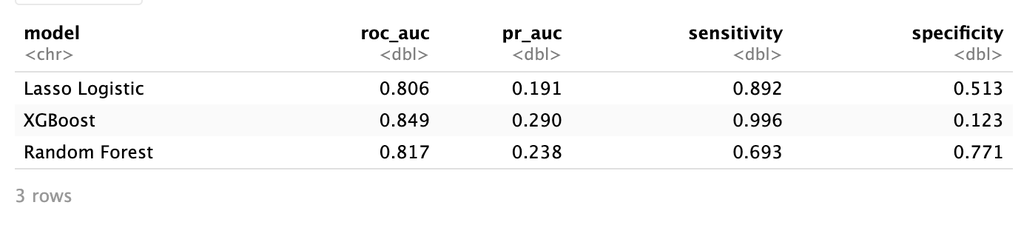

## Additional Analyses

The top 20 most important features in the Lasso Logistic Regression Model are:

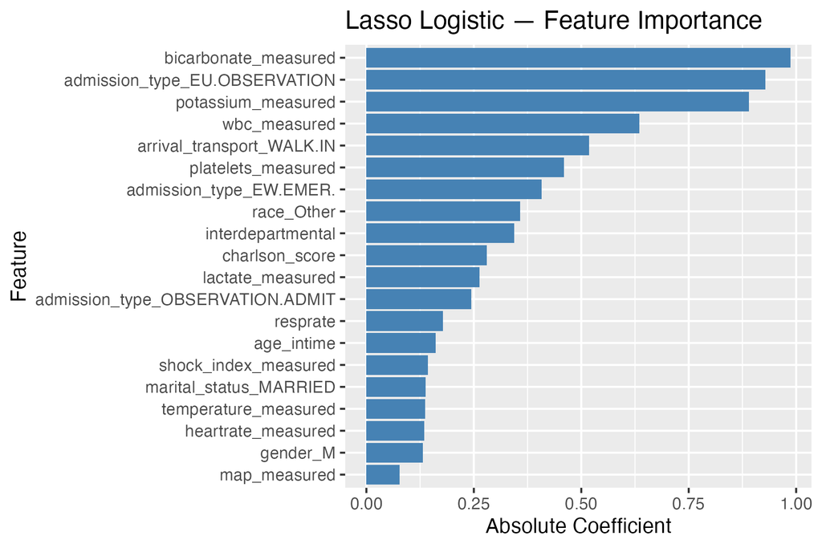

The top 20 most important features in the Random Forest Model are:

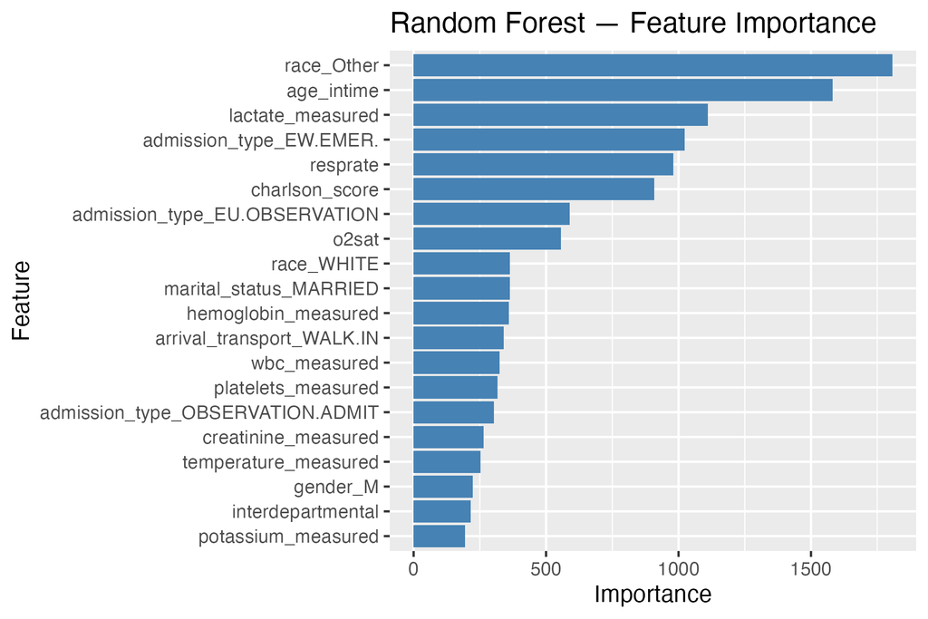

The top 20 most important features in the XGBoost Model are:

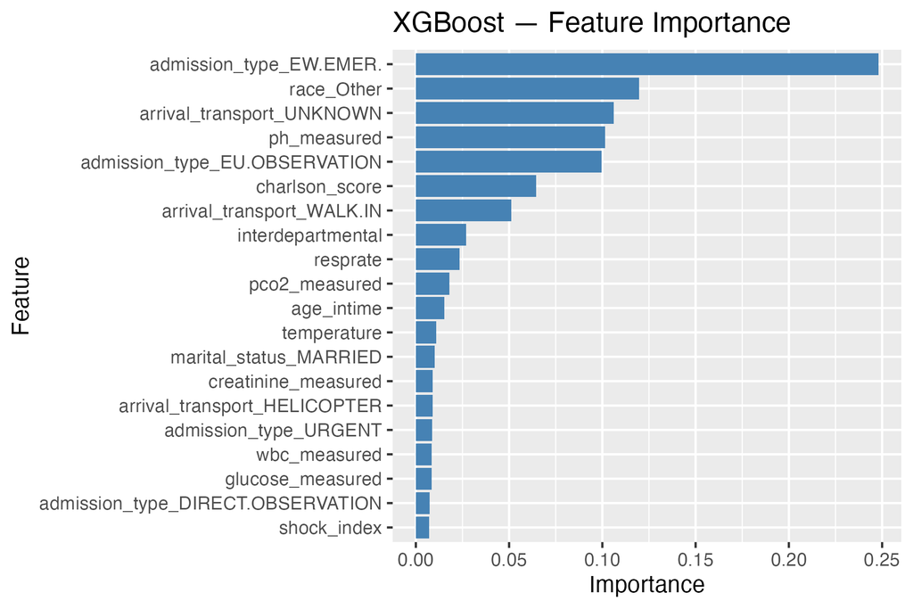

Overall, the most important features across all three models were admission type, specifically eu.observation and ew.emer, which are both types of admission from the ED and need additional care and observation, race, and labs, such as pH, lactate, bicarbonate, and potassium. Also, the chosen thresholds per model varied, with Random Forest having the lowest threshold of 0.05, Lasso Logistic Regression having a threshold of 0.34, and XGBoost having the highest threshold of 0.57, which could be due to the different ways each model calculates feature importance and makes predictions.

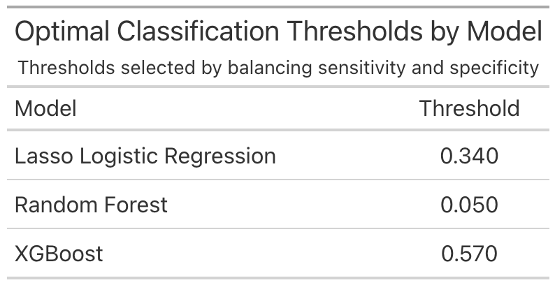

# Discussion

## Summary of Findings

With all 3 models having ROC-AUCs above 0.8, we can conclude that there is a strong signal in the data and that the features we selected are informative for predicting early ICU transfer among trauma patients in the ED, even with the severe class imbalance in the cohort. While there was some variation in the specific order of the most important features across the three models, there were some consistent themes. For example, admission type, specifically eu.observation and ew.emer, which are both types of admission from the ED and need additional care and observation, were among the most important features in all three models. This makes clinical sense, as patients who are admitted under these categories may be more likely to require critical care.

## Comparison with Previous Work

Previous studies have identified various factors associated with ICU admission from the ED, such as age, comorbidities, and certain abnormal lab values and vital signs (1). Our findings are consistent with these studies, as we also found that features such as age, comorbidities (as measured by the Charlson comorbidity index), and certain lab values (such as pH, lactate, bicarbonate, and potassium) were among the most important predictors of early ICU transfer in our models. Additionally, our finding that admission type is a key predictor of early ICU transfer is also consistent with previous research, as patients who require additional care and observation in the ED may be more likely to deteriorate and require critical care.

There was an interesting finding that race was among the most important predictors of early ICU transfer in all three models. This could be due to a variety of factors, including potential disparities in healthcare access and quality, differences in underlying health conditions, or other social determinants of health that may affect the likelihood of ICU transfer. This finding warrants further investigation to understand the underlying reasons for this association and to address any potential disparities in care.

## Strengths and Limitations

One of the strengths of this project is that we utilized a large, real-world dataset from the MIMIC-IV database, which contains detailed clinical data on a diverse population of patients. This allowed us to build a robust predictive model with good generalizability. Additionally, we compared multiple modeling approaches and evaluated their performance using a variety of metrics, which provided a comprehensive assessment of the models’ predictive capabilities. Utilizing only the first three hours of data from the ED also avoids data leakage and ensures that the model is making predictions based on information that would be available to clinicians at the time of decision-making. Also, addressing the class imbalance with class weights qualified our models to better identify the minority class, which is crucial for our clinical goal of prioritizing sensitivity.

However, there are also limitations to this project. One limitation is that the MIMIC-IV database is based on data from a single hospital, which may limit the generalization of our findings to other settings. Additionally, there may be unmeasured features that could affect the relationship between the predictor variables and the outcome variable, which could bias our results. Furthermore, while we included a variety of features in our models, there may be other relevant features that we did not include, such as specific clinical interventions or medications administered in the ED, which could potentially improve the model’s predictive performance. Lastly, while we prioritized sensitivity in our model evaluation, it came at a cost to specificity. If this model were to be implemented, the number of patients who would be chosen to be transferred to the ICU would be much higher than the number of patients who actually need to be transferred, which could lead to resource strain and potential harm from unnecessary transfers. Therefore, further work is needed to optimize the balance between sensitivity and specificity for clinical implementation. Furthermore, with over a majority of the features having a high percentage of missing values in the lab and vital data, there are pieces of information lost that can improve the model. If a better way to keep these pieces of information while also keeping the missing values to a minimum, the model performance will be much improved.

## Implications

The findings from this project have important implications for clinical practice. The predictive model we developed can potentially be used as a tool to help clinicians identify trauma patients in the ED who are at high risk of needing transfer to a CCU within 3 hours. This can help prioritize care and allocate resources more effectively, ultimately improving patient outcomes. For example, patients identified as high risk by the model could be monitored more closely, receive more aggressive interventions, or be prioritized for transfer to a CCU. Additionally, understanding the key predictors of early ICU transfer can provide insights into the clinical factors that contribute to deterioration in trauma patients in the ED, which can inform clinical decision-making and guide future research.

# Conclusion

In conclusion, our project demonstrates that it is possible to predict early ICU transfer among trauma patients in the ED using a variety of clinical features available within the first three hours of admission. The XGBoost model showed the best performance in identifying high-risk patients, with important predictors including admission type, race, and certain lab values. While there are limitations to our study, our findings have important implications for improving patient care and bed management in the ED and highlight the potential of predictive modeling in clinical decision-making. Future work should focus on optimizing the balance between sensitivity and specificity for clinical implementation, as well as exploring additional features and external validation to further improve the model’s performance and generalizability.

# References

1. Smith, G., & Nielsen, M. (1999). ABC of intensive care. Criteria for admission. BMJ (Clinical research ed.), 318(7197), 1544–1547. https://doi.org/10.1136/bmj.318.7197.1544
2. Özkaya, S., & Yurdakul, M. S. (2025). Impact of emergency department-to-intensive care unit transfer time on in-hospital mortality: A retrospective cohort study. Medicine, 104(51), e46724. https://doi.org/10.1097/MD.0000000000046724
3. Cha, J. H., Kang, D., Ko, R. E., Kim, W. Y., Hyun, D. G., Lee, Y. J., Cho, W. H., Park, S., Cho, J., & Suh, G. Y. (2025). Association between emergency department-to-intensive care unit transfer time and mortality in patients with septic shock: a target trial emulation with septic shock in South Korea. Acute and critical care, 40(4), 548–556. https://doi.org/10.4266/acc.003575

# AI Usage Acknowledgement

I utilized Claude Sonnet 4.6, GitHub Copilot, and Google Gemini 3 to assist coding the project. The models provided suggestions and helped with debugging. All code was reviewed and edited by me to ensure accuracy and appropriateness for the project. The models were used as tools to enhance the coding process, but all final decisions and code implementations were made by me. I also used Copilot’s suggestions in writing the report, but I revised and edited all statements to ensure accurate accounts of the project and to ensure that the writing style was consistent throughout the report of the project.

# Cohort

##Set-Up

```r
library(arrow)
library(bigrquery)
library(dbplyr)
library(DBI)
library(gt)
library(gtsummary)
library(tidyverse)
library(forcats)
library(pryr)
library(data.table)
library(comorbidity)
library(tidymodels)
library(vip)
library(duckdb)
library(probably)
library(doParallel)
library(parallel)
library(xgboost)
library(scales)  # for log10_trans()
library(ggplot2)
```

```r
# path to the service account token
satoken <- "biostat-203b-2026-winter-92fefbfab477.json"
# BigQuery authentication using service account
bq_auth(path = "~/BIOSTAT203B/203b-hw/hw4/biostat-203b-2026-winter-92fefbfab477.json")
```

Connect to BigQuery database `mimiciv_3_1` in GCP (Google Cloud Platform), using the project billing account `biostat-203b-2025-winter`.

```r
# connect to the BigQuery database `biostat-203b-2025-mimiciv_3_1`
con_bq <- dbConnect(
    bigrquery::bigquery(),
    project = "biostat-203b-2025-winter",
    dataset = "mimiciv_3_1",
    billing = "biostat-203b-2025-winter"
)
con_bq
```

```
<BigQueryConnection>
  Dataset: biostat-203b-2025-winter.mimiciv_3_1
  Billing: biostat-203b-2025-winter
```

## Building the cohort: Joining transfers and icustays together

```r
# find all units listed under icustays
icu_careunits <- tbl(con_bq, "icustays") %>%
  distinct(first_careunit) %>%
  pull(first_careunit)
```

```r
# all transfers of patients who go from ed to icu per visit
ed_to_icu <- tbl(con_bq, "transfers") %>% #start with transfers
  mutate(
    is_ed = careunit == "Emergency Department",
    is_icu = careunit %in% icu_careunits
  ) %>%
  group_by(subject_id, hadm_id) %>%
  window_order(intime) %>%
  mutate(
    is_last_ed = is_ed & !sql("LEAD(is_ed, 1, FALSE) OVER (
                      PARTITION BY subject_id, hadm_id
                      ORDER BY intime
                     )"),
    next_is_icu = sql("LEAD(is_icu, 1, FALSE) OVER (
                      PARTITION BY subject_id, hadm_id
                      ORDER BY intime
                     )")
  ) %>%
  mutate(
    any_next_icu = sql("MAX(next_is_icu) OVER (
                      PARTITION BY subject_id, hadm_id
                      ORDER BY intime
                      ROWS BETWEEN CURRENT ROW AND UNBOUNDED FOLLOWING
                     )")
  ) %>%
  ungroup() %>%
  filter(is_ed) %>%
  group_by(subject_id, hadm_id) %>%
  mutate( #can't use slice_min so we use row_number to get the first ed transfer per visit
    stay_num = sql("ROW_NUMBER() OVER (
                      PARTITION BY subject_id, hadm_id
                      ORDER BY intime
                     )")
  ) %>%
  filter(stay_num == 1) %>%
  ungroup() %>%
  left_join(
    tbl(con_bq, "icustays") %>%
      arrange(subject_id, hadm_id, intime) %>%
      group_by(subject_id, hadm_id) %>%
      filter(intime == min(intime)) %>%
      ungroup() %>%
      rename(intime_icu = intime, outtime_icu = outtime),
    by = c("subject_id", "hadm_id")
  ) %>%  # join in BQ
  select(-eventtype, -stay_num, -is_icu,
         -last_careunit, -los, -transfer_id) %>%
  collect()
```

```r
ed_to_icu <- ed_to_icu %>%
  mutate(
    icu_within_3hrs = if_else(
      !is.na(intime_icu) & !is.na(intime) &
      intime_icu >= intime &
      intime_icu <= intime + hours(3),
      1L, 0L),
  ed_to_icu_minutes = if_else(
      !is.na(intime_icu) & !is.na(intime),
      as.numeric(difftime(intime_icu, intime, units = "mins")),
      NA_real_
    )
  )
ed_to_icu
```

```
# A tibble: 594,678 × 15
   subject_id  hadm_id careunit    intime              outtime             is_ed
        <int>    <int> <chr>       <dttm>              <dttm>              <lgl>
 1   10000032 22595853 Emergency … 2180-05-06 19:17:00 2180-05-06 23:30:00 TRUE
 2   10006501       NA Emergency … 2172-01-09 13:03:00 2172-01-09 22:36:00 TRUE
 3   10007920       NA Emergency … 2132-03-17 12:07:00 2132-03-17 19:26:00 TRUE
 4   10009203 23598550 Emergency … 2201-08-12 14:22:00 2201-08-12 20:52:00 TRUE
 5   10015186 23922627 Emergency … 2123-11-05 18:34:00 2123-11-05 21:57:57 TRUE
 6   10017730       NA Emergency … 2137-08-18 11:54:00 2137-08-18 15:27:00 TRUE
 7   10018328       NA Emergency … 2154-08-03 15:31:00 2154-08-03 22:29:00 TRUE
 8   10024550       NA Emergency … 2124-06-09 21:27:00 2124-06-10 01:03:00 TRUE
 9   10026658 28457507 Emergency … 2150-02-05 18:02:00 2150-02-06 02:28:00 TRUE
10   10030377       NA Emergency … 2125-11-28 15:23:00 2125-11-28 18:43:00 TRUE
# ℹ 594,668 more rows
# ℹ 9 more variables: is_last_ed <lgl>, next_is_icu <lgl>, any_next_icu <lgl>,
#   stay_id <int>, first_careunit <chr>, intime_icu <dttm>, outtime_icu <dttm>,
#   icu_within_3hrs <int>, ed_to_icu_minutes <dbl>
```

## Finding all trauma patients through ICD codes

```r
all_trauma_patients <- tbl(con_bq, "diagnoses_icd") %>%
    filter(
      # ICD-10 Logic: Must be version 10 AND within the S00-T88 range
      (icd_version == 10 & icd_code >= "S00" & icd_code <= "T88") |

        # ICD-9 Logic: Must be version 9 AND (Numeric range OR E-code range)
        (icd_version == 9 & (
          (icd_code >= "800" & icd_code <= "959") |
            (icd_code >= "E800" & icd_code <= "E999")
        ))
  ) %>%
  left_join(
    tbl(con_bq, "d_icd_diagnoses"),
    by = c("icd_code", "icd_version")
  ) %>%
  collect()
```

```r
ed_to_icu_trauma <- ed_to_icu %>%
  semi_join(
    all_trauma_patients,
    by = c("subject_id", "hadm_id")
  )
```

## Now that we have all the patients and their stays, add in labs, vitals, and demographic data

```r
demographics <- tbl(con_bq, "patients") %>%
  select(subject_id, gender, anchor_age, anchor_year) %>%
  inner_join(
    tbl(con_bq, "admissions") %>%
      select(subject_id, hadm_id, insurance,
             race, marital_status, admission_type),
    by = "subject_id") %>%
  collect()

ed_to_icu_trauma_demo <- ed_to_icu_trauma %>%
  inner_join(
    demographics,
    by = c("subject_id", "hadm_id")
  )
```

```r
lab_items_map <- c(
  "51222" = "hemoglobin",
  "51265" = "platelets",
  "50862" = "albumin",
  "50912" = "creatinine",
  "50971" = "potassium",
  "50983" = "sodium",
  "50902" = "chloride",
  "50882" = "bicarbonate",
  "51221" = "hematocrit",
  "51301" = "wbc",
  "50931" = "glucose",
  "50820" = "pH",
  "50818" = "pCO2",
  "50821" = "pO2",
  "50817" = "Oxygen Saturation",
  "50802" = "Base Excess",
  "50813" = "Lactate",
  "51006" = "Urea Nitrogen"
)

lab_item_ids <- as.integer(names(lab_items_map))
```

```r
labevents_tble <-
  open_dataset("labevents_pq", format = "parquet") %>%
  select(subject_id, hadm_id, itemid, charttime, valuenum) %>%
  filter(itemid %in% lab_item_ids,
         !is.na(charttime),
         !is.na(valuenum)
  ) %>%
  mutate(
    subject_id = cast(subject_id, int32()),
    hadm_id = cast(hadm_id, int32()) ,
    charttime = cast(charttime, timestamp(unit = "us", timezone = "UTC"))
  )%>%
  inner_join(
    ed_to_icu_trauma_demo %>%
      select(subject_id, hadm_id, intime),
    by = c("subject_id", "hadm_id")
  ) %>%
  filter(!is.na(intime),
       charttime >= intime,
       charttime <= intime + dhours(3)
  ) %>%
  collect()

labs <- labevents_tble %>%
  group_by(subject_id, hadm_id, itemid) %>%
  slice_max(order_by = charttime, n = 1, with_ties = FALSE) %>%
  ungroup() %>%
  mutate(lab = recode(as.character(itemid), !!!lab_items_map)) %>%
  select(subject_id, hadm_id, lab, valuenum) %>%
  pivot_wider(names_from = lab, values_from = valuenum)

ed_to_icu_trauma_demo_labs <- ed_to_icu_trauma_demo %>%
  left_join(
    labs,
    by = c("subject_id", "hadm_id")
  )
```

## Adding the vitals from the ED dataset

```r
vitals <- fread("~/BIOSTAT203B/mimic-iv-3.1/ed/vitalsign.csv.gz") %>%
  as_tibble()
edstays <- fread("~/BIOSTAT203B/mimic-iv-3.1/ed/edstays.csv.gz") %>%
  as_tibble()
```

```r
ed_vitals <- vitals %>%
  select(subject_id, stay_id, charttime,
         temperature, heartrate, resprate,
         o2sat, sbp, dbp) %>%
  inner_join(
    edstays %>%
      select(subject_id, stay_id, hadm_id, intime, arrival_transport),
    by = c("subject_id", "stay_id")
  ) %>%
  filter(
     !is.na(intime),
     !is.na(charttime),
    charttime >= intime,
    charttime <= intime + hours(3)
  ) %>%
  pivot_longer(
    cols = c(temperature, heartrate, resprate, o2sat, sbp, dbp),
    names_to = "vital_name",
    values_to = "valuenum"
  ) %>%
  filter(!is.na(valuenum)) %>%
  group_by(subject_id, hadm_id, vital_name) %>%
  slice_max(order_by = charttime, n = 1, with_ties = FALSE) %>%
  ungroup() %>%
  pivot_wider(names_from = vital_name, values_from = valuenum) %>%
  collect() %>%
  select(-stay_id, -intime)
```

```r
ed_to_icu_trauma_demo_labs_vitals <- ed_to_icu_trauma_demo_labs %>%
  left_join(
    ed_vitals,
    by = c("subject_id", "hadm_id")
  )
rm(ed_to_icu_trauma_demo_labs)
rm(ed_vitals)
```

```r
ed_to_icu_trauma_demo_labs_vitals %>%
  group_by(icu_within_3hrs, next_is_icu) %>%
  count()
```

```
# A tibble: 4 × 3
# Groups:   icu_within_3hrs, next_is_icu [4]
  icu_within_3hrs next_is_icu     n
            <int> <lgl>       <int>
1               0 FALSE       52755
2               0 TRUE        67836
3               1 FALSE         103
4               1 TRUE         4877
```

```r
ed_to_icu_trauma_demo_labs_vitals %>%
  group_by(icu_within_3hrs) %>%
  count()
```

```
# A tibble: 2 × 2
# Groups:   icu_within_3hrs [2]
  icu_within_3hrs      n
            <int>  <int>
1               0 120591
2               1   4980
```

## Adding Charlson score to account for comorbidities

```r
icd_visits <- tbl(con_bq, "diagnoses_icd") %>%
  inner_join(
    tbl(con_bq, "admissions") %>%
    group_by(subject_id) %>%
    arrange(admittime) %>%
    mutate(
      stay_seq = row_number()
    ) %>%
    select(subject_id, hadm_id, stay_seq, admittime, dischtime),
    by = c("subject_id", "hadm_id")
  ) %>%
  collect()
```

```r
# get all the icd 9 codes that are needed for charlson score and see if a patient was diagnosed with them
map9 <- comorbidity(x = filter(icd_visits, icd_version == 9),
                    id = "hadm_id", code = "icd_code",
                    map = "charlson_icd9_quan", assign0 = TRUE)

# get all the icd 10 codes that are needed for charlson score and see if a patient was diagnosed with them
map10 <- comorbidity(x = filter(icd_visits, icd_version == 10),
                     id = "hadm_id", code = "icd_code",
                     map = "charlson_icd10_quan", assign0 = TRUE)

# put these maps together and join back into main dataset icd_visits
all_maps <- bind_rows(map9, map10) %>%
  group_by(hadm_id) %>%
  summarise(across(mi:aids, max)) %>%
  left_join(
    unique(select(icd_visits, subject_id, hadm_id, stay_seq)),
    by = "hadm_id"
  )

# make sure if previous stays have been diagnosed with certain code, future stays still have that recorded for patient history
final_cci <- all_maps %>%
  group_by(subject_id) %>%
  arrange(stay_seq) %>%
  mutate(across(mi:aids, ~ {
    # calculate cumulative history including current visit
    cum_history = cumany(.x == 1)
    # lag it by 1 so current visit only sees history from stay_seq - 1
    lag(cum_history, default = FALSE)
  })) %>%
  ungroup()

# for score to work, force meta tags to have class comorbidity and attributes to be charlson_icd10_quan
class(final_cci) <- c("comorbidity", class(final_cci))
attr(final_cci, "map") <- "charlson_icd10_quan"

# finally, weighted score based on all diagnoses
final_cci$charlson_score <- score(
  final_cci, weights = "quan", assign0 = TRUE
)
```

```r
# only keep the stays where we are interested in the ed to icu transfers
ed_to_icu_trauma_demo_labs_vitals_charlson <- final_cci %>%
  select(subject_id, hadm_id, stay_seq, charlson_score) %>%
  right_join(
    ed_to_icu_trauma_demo_labs_vitals,
    by = c("subject_id", "hadm_id")
  )
rm(ed_to_icu_trauma_demo_labs_vitals)
rm(icd_visits)
rm(map9)
rm(map10)
rm(all_maps)
rm(final_cci)
```

```r
ed_to_icu_trauma_demo_labs_vitals_charlson %>%
  tbl_summary(by = icu_within_3hrs) %>%
  add_n(statistic = "{p_miss}")
```

| **Characteristic** | **N** | **0** N = 120,591<sup>1</sup> | **1** N = 4,980<sup>1</sup> |
| --- | --- | --- | --- |
| subject_id | 0 | 14,993,854 (12,521,573, 17,480,646) | 14,940,169 (12,502,282, 17,534,287) |
| hadm_id | 0 | 25,010,068 (22,488,104, 27,510,158) | 24,977,874 (22,469,909, 27,383,983) |
| stay_seq | 0 | 2 (1, 5) | 1 (1, 2) |
| charlson_score | 0 | 0.00 (0.00, 3.00) | 0.00 (0.00, 1.00) |
| careunit | 0 |  |  |
| Emergency Department |  | 120,591 (100%) | 4,980 (100%) |
| intime | 0 | 2155-04-07 11:44:00 (2135-03-29 05:50:00, 2175-06-04 21:57:00) | 2153-03-08 18:41:00 (2133-03-02 13:51:30, 2174-03-28 07:16:00) |
| outtime | 0 | 2155-04-07 17:30:00 (2135-03-29 22:45:00, 2175-06-05 10:46:00) | 2153-03-08 20:03:00 (2133-03-02 16:05:30, 2174-03-28 09:13:41.5) |
| is_ed | 0 | 120,591 (100%) | 4,980 (100%) |
| is_last_ed | 0 | 120,296 (100%) | 4,975 (100%) |
| next_is_icu | 0 | 67,836 (56%) | 4,877 (98%) |
| any_next_icu | 0 | 78,203 (65%) | 4,980 (100%) |
| stay_id | 76 | 34,977,703 (32,490,608, 37,469,738) | 34,939,846 (32,383,967, 37,426,967) |
| Unknown |  | 95,848 | 0 |
| first_careunit | 76 |  |  |
| Cardiac Vascular Intensive Care Unit (CVICU) |  | 1,232 (5.0%) | 201 (4.0%) |
| Coronary Care Unit (CCU) |  | 1,899 (7.7%) | 430 (8.6%) |
| Intensive Care Unit (ICU) |  | 7 (<0.1%) | 1 (<0.1%) |
| Med/Surg |  | 1 (<0.1%) | 0 (0%) |
| Medical Intensive Care Unit (MICU) |  | 6,855 (28%) | 1,223 (25%) |
| Medical/Surgical Intensive Care Unit (MICU/SICU) |  | 4,755 (19%) | 546 (11%) |
| Medicine |  | 3 (<0.1%) | 1 (<0.1%) |
| Neuro Intermediate |  | 1,418 (5.7%) | 174 (3.5%) |
| Neuro Stepdown |  | 380 (1.5%) | 73 (1.5%) |
| Neuro Surgical Intensive Care Unit (Neuro SICU) |  | 565 (2.3%) | 126 (2.5%) |
| PACU |  | 32 (0.1%) | 4 (<0.1%) |
| Surgery/Trauma |  | 2 (<0.1%) | 0 (0%) |
| Surgery/Vascular/Intermediate |  | 24 (<0.1%) | 8 (0.2%) |
| Surgical Intensive Care Unit (SICU) |  | 3,386 (14%) | 623 (13%) |
| Trauma SICU (TSICU) |  | 4,184 (17%) | 1,570 (32%) |

[output cut: 126 more lines]

<sup>1</sup> Median (Q1, Q3); n (%)

## Feature Engineering and Preprocessing

```r
ed_to_icu_trauma_demo_labs_vitals_charl_flagged <- ed_to_icu_trauma_demo_labs_vitals_charlson %>%
  mutate(
    # vitals flags
    temperature_measured  = as.integer(!is.na(temperature)),
    heartrate_measured    = as.integer(!is.na(heartrate)),
    sbp_measured          = as.integer(!is.na(sbp)),
    dbp_measured          = as.integer(!is.na(dbp)),
    resprate_measured     = as.integer(!is.na(resprate)),
    o2sat_measured        = as.integer(!is.na(o2sat)),

    # lab flags
    lactate_measured      = as.integer(!is.na(Lactate)),
    hemoglobin_measured   = as.integer(!is.na(hemoglobin)),
    platelets_measured    = as.integer(!is.na(platelets)),
    wbc_measured          = as.integer(!is.na(wbc)),
    creatinine_measured   = as.integer(!is.na(creatinine)),
    sodium_measured       = as.integer(!is.na(sodium)),
    potassium_measured    = as.integer(!is.na(potassium)),
    bicarbonate_measured  = as.integer(!is.na(bicarbonate)),
    glucose_measured      = as.integer(!is.na(glucose)),
    bun_measured          = as.integer(!is.na("Urea Nitrogen")),
    ph_measured           = as.integer(!is.na(pH)),
    pco2_measured         = as.integer(!is.na(pCO2)),
    po2_measured          = as.integer(!is.na(pO2)),
    base_excess_measured  = as.integer(!is.na("Base Excess")),
    o2sat_measured        = as.integer(!is.na("Oxygen Saturation")),

    # computed features only where both components present
    shock_index           = if_else(!is.na(heartrate) & !is.na(sbp),
                                    heartrate / sbp, NA_real_),
    shock_index_measured  = as.integer(!is.na(shock_index)),
    map                   = if_else(!is.na(sbp) & !is.na(dbp),
                                    dbp + (1/3) * (sbp - dbp), NA_real_),
    map_measured          = as.integer(!is.na(map)),
    age_intime            = anchor_age + year(intime) - anchor_year,
    interdepartmental     = if_else(next_is_icu == FALSE & any_next_icu == TRUE, 1L, 0L),
    race = fct_collapse(race,
           ASIAN = str_subset(unique(race), "ASIAN"),
           BLACK = str_subset(unique(race), "BLACK"),
           HISPANIC = str_subset(unique(race), "HISPANIC"),
           WHITE = str_subset(unique(race), "WHITE"),
           other_level = "Other"),
    icu_within_3hrs = factor(icu_within_3hrs,
                             levels = c(1, 0),
                             labels = c("Yes", "No"))
  ) %>%
select(-careunit, -is_ed, -is_last_ed, -stay_id, -first_careunit,
       -intime_icu, -intime, -outtime_icu, outtime, -ed_to_icu_minutes,
       -anchor_year,
       -charttime, -"Oxygen Saturation", -next_is_icu, -any_next_icu,
       -intime, -outtime, -subject_id, -hadm_id)
  # drop all original continuous lab/vital columns
```

```r
final_cohort_flagged <- ed_to_icu_trauma_demo_labs_vitals_charl_flagged %>%
  select(-c(Lactate, hemoglobin, platelets, wbc, creatinine,
            sodium, potassium, bicarbonate, glucose, "Urea Nitrogen",
            pH, pCO2, pO2, "Base Excess", albumin, hematocrit,
            chloride, anchor_age))
```

## Cohort Summaries

```r
final_cohort_flagged %>%
  tbl_summary(by = icu_within_3hrs) %>%
  add_n(
    statistic = "{p_miss}"
  )
```

| **Characteristic** | **N** | **Yes** N = 4,980<sup>1</sup> | **No** N = 120,591<sup>1</sup> |
| --- | --- | --- | --- |
| stay_seq | 0 | 1 (1, 2) | 2 (1, 5) |
| charlson_score | 0 | 0.00 (0.00, 1.00) | 0.00 (0.00, 3.00) |
| gender | 0 |  |  |
| F |  | 2,000 (40%) | 59,598 (49%) |
| M |  | 2,980 (60%) | 60,993 (51%) |
| insurance | 2.3 |  |  |
| Medicaid |  | 854 (18%) | 21,158 (18%) |
| Medicare |  | 2,272 (48%) | 63,343 (54%) |
| No charge |  | 1 (<0.1%) | 11 (<0.1%) |
| Other |  | 176 (3.7%) | 3,282 (2.8%) |
| Private |  | 1,412 (30%) | 30,193 (26%) |
| Unknown |  | 265 | 2,604 |
| race | 0 |  |  |
| ASIAN |  | 112 (2.2%) | 3,841 (3.2%) |
| BLACK |  | 421 (8.5%) | 16,824 (14%) |
| HISPANIC |  | 199 (4.0%) | 6,041 (5.0%) |
| WHITE |  | 2,846 (57%) | 85,475 (71%) |
| Other |  | 1,402 (28%) | 8,410 (7.0%) |
| marital_status | 3.5 |  |  |
| DIVORCED |  | 278 (7.0%) | 9,630 (8.2%) |
| MARRIED |  | 1,770 (44%) | 46,109 (39%) |
| SINGLE |  | 1,488 (37%) | 45,091 (38%) |
| WIDOWED |  | 458 (11%) | 16,396 (14%) |
| Unknown |  | 986 | 3,365 |
| admission_type | 0 |  |  |
| AMBULATORY OBSERVATION |  | 0 (0%) | 36 (<0.1%) |
| DIRECT EMER. |  | 20 (0.4%) | 474 (0.4%) |
| DIRECT OBSERVATION |  | 2 (<0.1%) | 1,745 (1.4%) |
| ELECTIVE |  | 1 (<0.1%) | 25 (<0.1%) |
| EU OBSERVATION |  | 65 (1.3%) | 23,119 (19%) |

[output cut: 54 more lines]

<sup>1</sup> Median (Q1, Q3); n (%)

```r
saveRDS(final_cohort_flagged, "final_cohort_flagged.rds")
```

```r
readRDS("final_cohort_flagged.rds") %>%
  tbl_summary(by = icu_within_3hrs) %>%
  add_n(
    statistic = "{p_miss}"
  ) %>%
  as_gt() %>%
  tab_header(
    title = "Cohort Summary Table",
    subtitle = "Summary of trauma patients stays in the ED, stratified by whether they were transferred to a CCU within 3 hours"
  ) %>%
  gtsave("cohort_summary.png")
```

```
file:////var/folders/_b/316cbm7s35x6v1s6jphxzz140000gn/T//RtmpxfQj4t/file1188042e953b4.html screenshot completed
```

#Lasso Logsitic Model ## Data Split Adding sample-based class weights to address class imbalance and then doing the intial data split with a proportion of 0.75 for training and 0.25 for testing, stratified by the outcome variable `icu_within_3hrs`.

```r
set.seed(123)
final_cohort_flagged <- readRDS("final_cohort_flagged.rds") %>%
  select(-stay_seq)

n_total <- nrow(final_cohort_flagged)
n_no <- sum(final_cohort_flagged$icu_within_3hrs == "No")
n_yes <- sum(final_cohort_flagged$icu_within_3hrs == "Yes")


cohort_w1 <- final_cohort_flagged %>%
  mutate(class_weight = if_else(icu_within_3hrs == "Yes",
                        n_total / (2 * n_yes),
                        n_total / (2 * n_no)),
         class_weight = importance_weights(class_weight))

data_split_w1 <- initial_split(
  cohort_w1,
  strata = icu_within_3hrs,
  prop = 0.75
)

train_data_w1 <- training(data_split_w1)
test_data_w1 <- testing(data_split_w1)

levels(cohort_w1$icu_within_3hrs)
```

```
[1] "Yes" "No"
```

## Workflow Recipe, Preprocessing, & Model Specification

```r
lassologit_recipe_w1 <-
  recipe(icu_within_3hrs ~ .,
         data = train_data_w1) %>%
  # mode imputation for insurance
  step_impute_mode(insurance) %>%
  # mode imputation for marital status
  step_impute_mode(marital_status) %>%
  # mode imputation for arrival_transport
  step_impute_mode(arrival_transport) %>%
  # median imputation for all vitals due to >50% & <65% missingness
  step_impute_median(temperature) %>%
  step_impute_median(heartrate) %>%
  step_impute_median(sbp) %>%
  step_impute_median(dbp) %>%
  step_impute_median(resprate) %>%
  step_impute_median(o2sat) %>%
  step_impute_median(map) %>%
  step_impute_median(shock_index) %>%
  # create traditional dummy variables
  step_dummy(all_nominal_predictors()) %>%
  # zero-variance filter
  step_nzv(all_predictors()) %>%
  # center and scale numeric features
  step_normalize(all_numeric_predictors())
```

```r
 lassologit_mod <-
   logistic_reg(
     penalty = tune(),
     mixture = 1
   ) %>%
   set_engine("glmnet", standardize = FALSE) %>%
   set_mode("classification")
```

```r
lassologit_wf_w1 <- workflow() %>%
  add_case_weights(class_weight) %>%
  add_model(lassologit_mod) %>%
  add_recipe(lassologit_recipe_w1) %>%
  print()
```

```
══ Workflow ════════════════════════════════════════════════════════════════════
Preprocessor: Recipe
Model: logistic_reg()

── Preprocessor ────────────────────────────────────────────────────────────────
14 Recipe Steps

• step_impute_mode()
• step_impute_mode()
• step_impute_mode()
• step_impute_median()
• step_impute_median()
• step_impute_median()
• step_impute_median()
• step_impute_median()
• step_impute_median()
• step_impute_median()
• ...
• and 4 more steps.

── Case Weights ────────────────────────────────────────────────────────────────
class_weight

── Model ───────────────────────────────────────────────────────────────────────
Logistic Regression Model Specification (classification)

Main Arguments:
  penalty = tune()
  mixture = 1

Engine-Specific Arguments:
  standardize = FALSE

Computational engine: glmnet
```

## Tuning Penalty

Using cross validation to tune the penalty parameter for the lasso logistic regression model, using a grid of 50 values for the penalty parameter ranging from 10^-8 to 10^1 on the log scale. Evaluating model performance using AUC-ROC, AUC-PR, sensitivity, and specificity metrics.

```r
n_cores <- detectCores(logical = TRUE) - 1
cl <- makePSOCKcluster(n_cores)
registerDoParallel(cl)
cat("Running on", n_cores, "cores\n")
```

```
Running on 7 cores
```

```r
set.seed(123)
folds <- vfold_cv(train_data_w1,
                  v = 5,
                  strata = icu_within_3hrs)

param_grid <- grid_regular(
  penalty(range = c(-8,1), trans = log10_trans()),
   levels = 50
  )

lassologit_fit_w1 <- lassologit_wf_w1 %>%
  tune_grid(
    resamples = folds,
    grid = param_grid,
    control = control_grid(save_pred = TRUE,
                           parallel_over = "everything"),
    metrics = metric_set(roc_auc, pr_auc, sensitivity, specificity)
  )

stopCluster(cl)
registerDoSEQ()
cat("Parallel cluster stopped\n")
```

```
Parallel cluster stopped
```

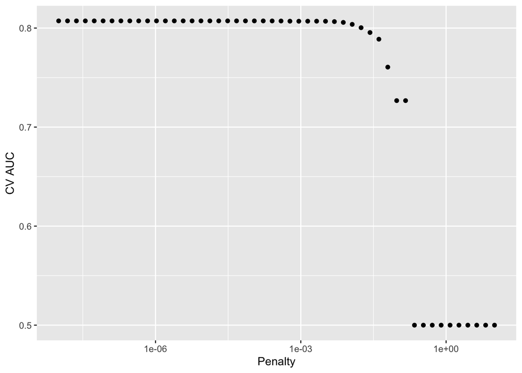

```r
lassologit_fit_w1 %>%
  collect_metrics() %>%
  filter(.metric == "roc_auc") %>%
  ggplot(mapping = aes(x = penalty, y = mean)) +
  geom_point() +
  labs(x = "Penalty", y = "CV AUC") +
  scale_x_log10()
```

```r
lassologit_fit_w1 %>%
  show_best(metric = "roc_auc")
```

```
# A tibble: 5 × 7
       penalty .metric .estimator  mean     n std_err .config
         <dbl> <chr>   <chr>      <dbl> <int>   <dbl> <chr>
1 0.00000001   roc_auc binary     0.807     5 0.00294 pre0_mod01_post0
2 0.0000000153 roc_auc binary     0.807     5 0.00294 pre0_mod02_post0
3 0.0000000233 roc_auc binary     0.807     5 0.00294 pre0_mod03_post0
4 0.0000000356 roc_auc binary     0.807     5 0.00294 pre0_mod04_post0
5 0.0000000543 roc_auc binary     0.807     5 0.00294 pre0_mod05_post0
```

```r
best_lassologit_w1 <- lassologit_fit_w1 %>%
  select_best(metric = "roc_auc")
best_lassologit_w1
```

```
# A tibble: 1 × 2
     penalty .config
       <dbl> <chr>
1 0.00000001 pre0_mod01_post0
```

## Tuning Threshold

After finding the best model based on the tuning results, we collect the predictions from the cross validation folds for that best model and then use the `threshold_perf()` function to calculate sensitivity and specificity across a range of classification thresholds from 0.05 to 0.7, and then plot these metrics across the thresholds to visually inspect where we can achieve at least 90% sensitivity while maximizing specificity.

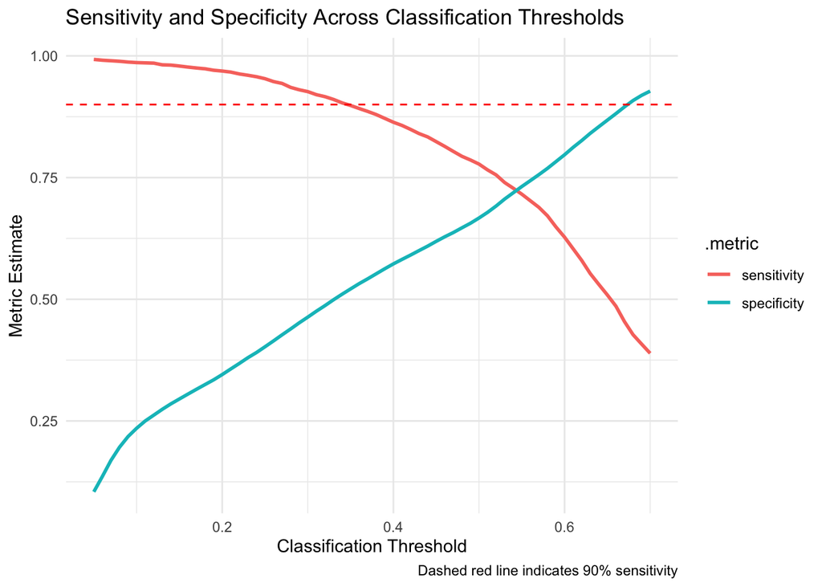

```r
cv_preds <- lassologit_fit_w1 %>%
  collect_predictions(parameters = best_lassologit_w1)

threshold_data <- cv_preds %>%
  threshold_perf(truth = icu_within_3hrs,
                 estimate = .pred_Yes,
                 thresholds = seq(0.05, 0.7, by = 0.01),
                 metrics = metric_set(sensitivity, specificity, j_index))

threshold_data %>%
  filter(.metric %in% c("sensitivity", "specificity")) %>%
  ggplot(aes(x = .threshold, y = .estimate, color = .metric)) +
    geom_line(linewidth = 1) +
    geom_hline(yintercept = 0.90, linetype = "dashed", color = "red") +
    labs(x = "Classification Threshold",
         y = "Metric Estimate",
         title = "Sensitivity and Specificity Across Classification Thresholds",
         caption = "Dashed red line indicates 90% sensitivity") +
    theme_minimal()
```

```r
lassologit_chosen_threshold <- threshold_data %>%
  filter(.metric == "sensitivity", .estimate >= 0.90) %>%
  slice_max(order_by = .threshold) %>%
  pull(.threshold)

cat("Chosen threshold:", lassologit_chosen_threshold, "\n")
```

```
Chosen threshold: 0.34
```

## Fitting Best Model and Evaluation Performance

Once threshold is chosen, we fit the best model on the whole dataset and evaluate its performance on the test set, and then we also look at the coefficients of the fitted model to see which features were most important in predicting whether a patient would be transferred to the ICU within 3 hours of ED presentation.

```r
final_lassologit_wf_w1 <- lassologit_wf_w1 %>%
  finalize_workflow(best_lassologit_w1)

final_lassologit_fit_w1 <- final_lassologit_wf_w1 %>%
  last_fit(split = data_split_w1,
           metrics = metric_set(roc_auc, pr_auc, sensitivity, specificity, precision, recall, f_meas))
```

```r
final_lassologit_fit_w1 %>%
  collect_metrics()
```

```
# A tibble: 7 × 4
  .metric     .estimator .estimate .config
  <chr>       <chr>          <dbl> <chr>
1 sensitivity binary        0.772  pre0_mod0_post0
2 specificity binary        0.669  pre0_mod0_post0
3 precision   binary        0.0910 pre0_mod0_post0
4 recall      binary        0.772  pre0_mod0_post0
5 f_meas      binary        0.163  pre0_mod0_post0
6 roc_auc     binary        0.805  pre0_mod0_post0
7 pr_auc      binary        0.191  pre0_mod0_post0
```

## Confusion Matrix

```r
lassologit_preds <- final_lassologit_fit_w1 %>%
  collect_predictions() %>%
  mutate(.pred_class = if_else(.pred_Yes >= lassologit_chosen_threshold, "Yes", "No"),
         .pred_class = factor(.pred_class, levels = c("Yes", "No")))

conf_mat(lassologit_preds, truth = icu_within_3hrs, estimate = .pred_class)
```

```
          Truth
Prediction   Yes    No
       Yes  1149 14668
       No    142 15434
```

```r
metric_set(sensitivity, specificity, precision, recall, f_meas)(
  lassologit_preds,
  truth = icu_within_3hrs,
  estimate = .pred_class
  )
```

```
# A tibble: 5 × 3
  .metric     .estimator .estimate
  <chr>       <chr>          <dbl>
1 sensitivity binary        0.890
2 specificity binary        0.513
3 precision   binary        0.0726
4 recall      binary        0.890
5 f_meas      binary        0.134
```

## Feature Importance

```r
# ── 12. Variable Importance ───────────────────────────────────────────────────
fit_parsnip_w1     <- extract_fit_parsnip(final_lassologit_fit_w1)
coefficients_df_w1 <- tidy(fit_parsnip_w1)
coefficients_df_w1
```

```
# A tibble: 35 × 3
   term                  estimate    penalty
   <chr>                    <dbl>      <dbl>
 1 (Intercept)           8.48e- 1 0.00000001
 2 charlson_score        2.81e- 1 0.00000001
 3 o2sat                -1.87e- 3 0.00000001
 4 resprate             -1.78e- 1 0.00000001
 5 temperature_measured -1.36e- 1 0.00000001
 6 heartrate_measured   -1.35e- 1 0.00000001
 7 sbp_measured         -3.21e- 2 0.00000001
 8 dbp_measured         -7.53e-16 0.00000001
 9 resprate_measured     3.43e- 2 0.00000001
10 lactate_measured     -2.63e- 1 0.00000001
# ℹ 25 more rows
```

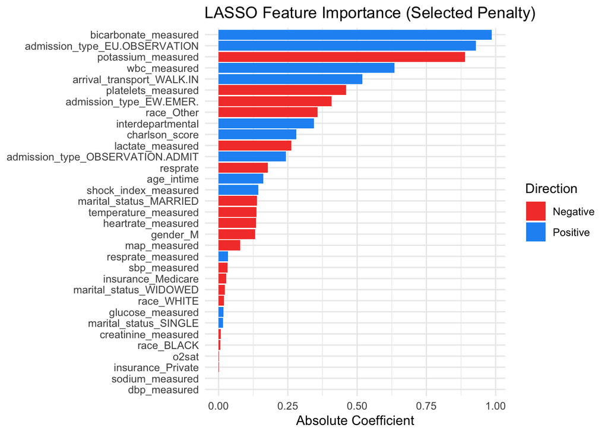

```r
# Plot importance from tidy() — this uses the correct selected penalty
# vip() is NOT used here because it reads from the wrong lambda on the glmnet path
coefficients_df_w1 %>%
  filter(
    term != "(Intercept)",
    estimate != 0            # only features LASSO kept
  ) %>%
  mutate(
    term = reorder(term, abs(estimate)),
    direction = if_else(estimate > 0, "Positive", "Negative")
  ) %>%
  ggplot(aes(x = abs(estimate), y = term, fill = direction)) +
  geom_col() +
  scale_fill_manual(values = c("Positive" = "#2196F3", "Negative" = "#F44336")) +
  labs(
    title = "LASSO Feature Importance (Selected Penalty)",
    x = "Absolute Coefficient",
    y = NULL,
    fill = "Direction"
  ) +
  theme_minimal()
```

## Save Lasso Logistic Regression Model

```r
lassologit_wf_final <- final_lassologit_fit_w1 %>%
  extract_workflow()

saveRDS(
  list(
    model = lassologit_wf_final,
    threshold = lassologit_chosen_threshold
    ),
  "lassologit.rds"
)
```

#Random Forest Model

## Data Split

```r
set.seed(123)

cohort_rf <- readRDS("final_cohort_flagged.rds") %>%
  select(-stay_seq)

data_split_rf <- initial_split(
  cohort_rf,
  strata = icu_within_3hrs,
  prop = 0.75
)

train_data_rf <- training(data_split_rf)
test_data_rf <- testing(data_split_rf)

levels(cohort_rf$icu_within_3hrs)
```

```
[1] "Yes" "No"
```

## Preprocessing and Model Specification

```r
rf_recipe <-
  recipe(icu_within_3hrs ~ .,
         data = train_data_rf) %>%
  # mode imputation for insurance
  step_impute_mode(insurance) %>%
  # mode imputation for marital status
  step_impute_mode(marital_status) %>%
  # mode imputation for arrival_transport
  step_impute_mode(arrival_transport) %>%
  # median imputation for all vitals due to >50% & <65% missingness
  step_impute_median(temperature) %>%
  step_impute_median(heartrate) %>%
  step_impute_median(sbp) %>%
  step_impute_median(dbp) %>%
  step_impute_median(resprate) %>%
  step_impute_median(o2sat) %>%
  step_impute_median(map) %>%
  step_impute_median(shock_index) %>%
  step_dummy(all_nominal_predictors()) %>%
  # zero-variance filter
  step_nzv(all_predictors())
```

```r
class_counts <- table(train_data_rf$icu_within_3hrs)
class_counts
```

```
  Yes    No
 3689 90489
```

```r
weight_no <- 1
weight_yes <- as.numeric(class_counts[2] / class_counts[1])

rf_mod <- rand_forest(
  mode = "classification",
  trees = 100,
  mtry = tune(), # num of features tested at each split
  min_n = tune() # min obs need to split a node
  ) %>%
  set_engine("ranger",
             importance = "impurity",
             class.weights = c("Yes" = weight_yes, "No" = weight_no),
             num.threads  = parallel::detectCores() - 1
)
```

## Pipeline Creation

```r
rf_wf <- workflow() %>%
  add_model(rf_mod) %>%
  add_recipe(rf_recipe)
```

## Hyperparameter Tuning with Cross Validation

```r
folds <- vfold_cv(train_data_rf,
                  v = 5,
                  strata = icu_within_3hrs)

rf_fit <- rf_wf %>%
tune_grid(
  resamples = folds,
  grid = 20,
  metrics = metric_set(roc_auc, pr_auc),
  control = control_grid(verbose = TRUE,
                         save_pred = TRUE,
                         parallel_over = "everything")
)
```

[output not shown]

[output not shown]

[output not shown]

[output not shown]

[output not shown]

[output not shown]

[output not shown]

[output not shown]

[output not shown]

[output not shown]

[output not shown]

[output not shown]

[output not shown]

[output not shown]

[output not shown]

[output not shown]

[output not shown]

[output not shown]

[output not shown]

[output not shown]

[output not shown]

[output not shown]

[output not shown]

[output not shown]

[output not shown]

[output not shown]

[output not shown]

[output not shown]

[output not shown]

[output not shown]

[output not shown]

[output not shown]

[output not shown]

[output not shown]

[output not shown]

[output not shown]

[output not shown]

[output not shown]

[output not shown]

[output not shown]

[output not shown]

[output not shown]

[output not shown]

[output not shown]

[output not shown]

[output not shown]

[output not shown]

[output not shown]

[output not shown]

[output not shown]

[output not shown]

[output not shown]

[output not shown]

[output not shown]

[output not shown]

[output not shown]

[output not shown]

[output not shown]

[output not shown]

[output not shown]

[output not shown]

[output not shown]

[output not shown]

[output not shown]

[output not shown]

[output not shown]

[output not shown]

[output not shown]

[output not shown]

[output not shown]

[output not shown]

[output not shown]

[output not shown]

[output not shown]

[output not shown]

[output not shown]

[output not shown]

[output not shown]

[output not shown]

[output not shown]

[output not shown]

[output not shown]

[output not shown]

[output not shown]

[output not shown]

[output not shown]

[output not shown]

[output not shown]

[output not shown]

[output not shown]

[output not shown]

[output not shown]

[output not shown]

[output not shown]

[output not shown]

[output not shown]

[output not shown]

[output not shown]

[output not shown]

[output not shown]

[output not shown]

[output not shown]

[output not shown]

[output not shown]

[output not shown]

[output not shown]

[output not shown]

[output not shown]

[output not shown]

[output not shown]

[output not shown]

[output not shown]

[output not shown]

[output not shown]

[output not shown]

[output not shown]

[output not shown]

[output not shown]

[output not shown]

[output not shown]

[output not shown]

[output not shown]

[output not shown]

[output not shown]

[output not shown]

[output not shown]

[output not shown]

[output not shown]

[output not shown]

[output not shown]

[output not shown]

[output not shown]

[output not shown]

[output not shown]

[output not shown]

[output not shown]

[output not shown]

[output not shown]

[output not shown]

[output not shown]

[output not shown]

[output not shown]

[output not shown]

[output not shown]

[output not shown]

[output not shown]

[output not shown]

[output not shown]

[output not shown]

[output not shown]

[output not shown]

[output not shown]

[output not shown]

[output not shown]

[output not shown]

[output not shown]

[output not shown]

[output not shown]

[output not shown]

[output not shown]

[output not shown]

[output not shown]

[output not shown]

[output not shown]

[output not shown]

[output not shown]

[output not shown]

[output not shown]

[output not shown]

[output not shown]

[output not shown]

[output not shown]

[output not shown]

[output not shown]

[output not shown]

[output not shown]

[output not shown]

[output not shown]

[output not shown]

[output not shown]

[output not shown]

[output not shown]

[output not shown]

[output not shown]

[output not shown]

[output not shown]

[output not shown]

[output not shown]

[output not shown]

[output not shown]

[output not shown]

[output not shown]

[output not shown]

[output not shown]

[output not shown]

[output not shown]

[output not shown]

[output not shown]

[output not shown]

[output not shown]

[output not shown]

[output not shown]

[output not shown]

[output not shown]

[output not shown]

[output not shown]

[output not shown]

[output not shown]

[output not shown]

[output not shown]

[output not shown]

[output not shown]

[output not shown]

[output not shown]

[output not shown]

[output not shown]

[output not shown]

[output not shown]

[output not shown]

[output not shown]

[output not shown]

[output not shown]

[output not shown]

[output not shown]

[output not shown]

[output not shown]

[output not shown]

[output not shown]

[output not shown]

[output not shown]

[output not shown]

[output not shown]

[output not shown]

[output not shown]

[output not shown]

[output not shown]

[output not shown]

[output not shown]

[output not shown]

[output not shown]

[output not shown]

[output not shown]

[output not shown]

[output not shown]

[output not shown]

[output not shown]

[output not shown]

[output not shown]

[output not shown]

[output not shown]

[output not shown]

[output not shown]

[output not shown]

[output not shown]

[output not shown]

[output not shown]

[output not shown]

[output not shown]

[output not shown]

[output not shown]

[output not shown]

[output not shown]

[output not shown]

[output not shown]

[output not shown]

[output not shown]

[output not shown]

[output not shown]

[output not shown]

[output not shown]

[output not shown]

[output not shown]

[output not shown]

[output not shown]

[output not shown]

[output not shown]

[output not shown]

[output not shown]

[output not shown]

[output not shown]

[output not shown]

[output not shown]

[output not shown]

[output not shown]

[output not shown]

[output not shown]

[output not shown]

[output not shown]

[output not shown]

[output not shown]

[output not shown]

[output not shown]

[output not shown]

[output not shown]

[output not shown]

[output not shown]

[output not shown]

[output not shown]

[output not shown]

[output not shown]

[output not shown]

```r
best_params <- select_best(
  rf_fit,
  metric = "roc_auc"
)

best_params
```

```
# A tibble: 1 × 3
   mtry min_n .config
  <int> <int> <chr>
1     4    34 pre0_mod03_post0
```

```r
best_pr_auc_params <- select_best(
  rf_fit,
  metric = "pr_auc"
)

best_pr_auc_params
```

```
# A tibble: 1 × 3
   mtry min_n .config
  <int> <int> <chr>
1     4    34 pre0_mod03_post0
```